# Explore and Summarize Data UDACITY TERM 2 PROJECT 2

mohit patel

15 May 2018

```
## [1] "C:/Users/lenovo/Documents/Udacity/project/Explore"
```

The variable *X* is not mentioned in the text file describing the dataset. A quick look at the dataframe reveals that it is just a unique identifier for every observation. It may be useful later, so we can keep it but change the name in order to avoid confusion.

```
## 'data.frame':    1599 obs. of  13 variables:
##  $ id                  : int  1 2 3 4 5 6 7 8 9 10 ...
##  $ fixed.acidity       : num  7.4 7.8 7.8 11.2 7.4 7.4 7.9 7.3 7.8 7.5 ...
##  $ volatile.acidity    : num  0.7 0.88 0.76 0.28 0.7 0.66 0.6 0.65 0.58 0.5 ...
##  $ citric.acid         : num  0 0 0.04 0.56 0 0 0.06 0 0.02 0.36 ...
##  $ residual.sugar      : num  1.9 2.6 2.3 1.9 1.9 1.8 1.6 1.2 2 6.1 ...
##  $ chlorides           : num  0.076 0.098 0.092 0.075 0.076 0.075 0.069 0.065 0.073 0.071 ...
##  $ free.sulfur.dioxide : num  11 25 15 17 11 13 15 15 9 17 ...
##  $ total.sulfur.dioxide: num  34 67 54 60 34 40 59 21 18 102 ...
##  $ density             : num  0.998 0.997 0.997 0.998 0.998 ...
##  $ pH                  : num  3.51 3.2 3.26 3.16 3.51 3.51 3.3 3.39 3.36 3.35 ...
##  $ sulphates           : num  0.56 0.68 0.65 0.58 0.56 0.56 0.46 0.47 0.57 0.8 ...
##  $ alcohol             : num  9.4 9.8 9.8 9.8 9.4 9.4 9.4 10 9.5 10.5 ...
##  $ quality             : int  5 5 5 6 5 5 5 7 7 5 ...
```

The variable *quality* has a very limited number of values. We can convert it to a factor.

It looks like all *free.sulfur.dioxide* and *total.sulfur.dioxide* values are whole numbers. It turns out this is true except for a few cases within each variable, all of them having exactly half a unit more:

```
## [1] 40.5  5.5 37.5 37.5
```

```
## [1] 77.5 77.5
```

My guess is that this is due to these two variables being measured in (mg/dm<sup>3</sup>), while the rest are in (g/dm<sup>3</sup>). I suppose that more precision is not needed and/or impossible to measure with the available resources.

```
##        id         fixed.acidity   volatile.acidity  citric.acid
##  Min.   :   1.0   Min.   : 4.60   Min.   :0.1200   Min.   :0.000
##  1st Qu.: 400.5   1st Qu.: 7.10   1st Qu.:0.3900   1st Qu.:0.090
##  Median : 800.0   Median : 7.90   Median :0.5200   Median :0.260
##  Mean   : 800.0   Mean   : 8.32   Mean   :0.5278   Mean   :0.271
##  3rd Qu.:1199.5   3rd Qu.: 9.20   3rd Qu.:0.6400   3rd Qu.:0.420
##  Max.   :1599.0   Max.   :15.90   Max.   :1.5800   Max.   :1.000
##  residual.sugar     chlorides       free.sulfur.dioxide
##  Min.   : 0.900   Min.   :0.01200   Min.   : 1.00
##  1st Qu.: 1.900   1st Qu.:0.07000   1st Qu.: 7.00
##  Median : 2.200   Median :0.07900   Median :14.00
##  Mean   : 2.539   Mean   :0.08747   Mean   :15.87
##  3rd Qu.: 2.600   3rd Qu.:0.09000   3rd Qu.:21.00
##  Max.   :15.500   Max.   :0.61100   Max.   :72.00
##  total.sulfur.dioxide    density             pH          sulphates
##  Min.   :  6.00       Min.   :0.9901   Min.   :2.740   Min.   :0.3300
##  1st Qu.: 22.00       1st Qu.:0.9956   1st Qu.:3.210   1st Qu.:0.5500
##  Median : 38.00       Median :0.9968   Median :3.310   Median :0.6200
##  Mean   : 46.47       Mean   :0.9967   Mean   :3.311   Mean   :0.6581
##  3rd Qu.: 62.00       3rd Qu.:0.9978   3rd Qu.:3.400   3rd Qu.:0.7300
##  Max.   :289.00       Max.   :1.0037   Max.   :4.010   Max.   :2.0000
##     alcohol      quality
##  Min.   : 8.40   3: 10
##  1st Qu.: 9.50   4: 53
##  Median :10.20   5:681
##  Mean   :10.42   6:638
##  3rd Qu.:11.10   7:199
##  Max.   :14.90   8: 18
```

There are some variables with possible outliers: *volatile.acidity*, *citric.acid*, *residual.sugar*, *chlorides*, *free.sulfur.dioxide* and *total.sulfur.dioxide* and *sulphates* have maximum values that are far away from the third quartile.

For the future, it would be interesting to have a summary of the dataset per quality rating:

```
## data$quality: 3
##        id         fixed.acidity    volatile.acidity  citric.acid
##  Min.   : 460.0   Min.   : 6.700   Min.   :0.4400   Min.   :0.0000
##  1st Qu.: 726.5   1st Qu.: 7.150   1st Qu.:0.6475   1st Qu.:0.0050
##  Median :1100.0   Median : 7.500   Median :0.8450   Median :0.0350
##  Mean   :1053.2   Mean   : 8.360   Mean   :0.8845   Mean   :0.1710
##  3rd Qu.:1446.2   3rd Qu.: 9.875   3rd Qu.:1.0100   3rd Qu.:0.3275
##  Max.   :1506.0   Max.   :11.600   Max.   :1.5800   Max.   :0.6600
##  residual.sugar    chlorides      free.sulfur.dioxide total.sulfur.dioxide
##  Min.   :1.200   Min.   :0.0610   Min.   : 3.0        Min.   : 9.0
##  1st Qu.:1.875   1st Qu.:0.0790   1st Qu.: 5.0        1st Qu.:12.5
##  Median :2.100   Median :0.0905   Median : 6.0        Median :15.0
##  Mean   :2.635   Mean   :0.1225   Mean   :11.0        Mean   :24.9
##  3rd Qu.:3.100   3rd Qu.:0.1430   3rd Qu.:14.5        3rd Qu.:42.5
##  Max.   :5.700   Max.   :0.2670   Max.   :34.0        Max.   :49.0
##     density             pH          sulphates         alcohol
##  Min.   :0.9947   Min.   :3.160   Min.   :0.4000   Min.   : 8.400
##  1st Qu.:0.9961   1st Qu.:3.312   1st Qu.:0.5125   1st Qu.: 9.725
##  Median :0.9976   Median :3.390   Median :0.5450   Median : 9.925
##  Mean   :0.9975   Mean   :3.398   Mean   :0.5700   Mean   : 9.955
##  3rd Qu.:0.9988   3rd Qu.:3.495   3rd Qu.:0.6150   3rd Qu.:10.575
##  Max.   :1.0008   Max.   :3.630   Max.   :0.8600   Max.   :11.000
##  quality
##  3:10
##  4: 0
##  5: 0
##  6: 0
##  7: 0
##  8: 0
## --------------------------------------------------------
## data$quality: 4
##        id       fixed.acidity    volatile.acidity  citric.acid
##  Min.   :  19   Min.   : 4.600   Min.   :0.230    Min.   :0.0000
##  1st Qu.: 262   1st Qu.: 6.800   1st Qu.:0.530    1st Qu.:0.0300
##  Median : 831   Median : 7.500   Median :0.670    Median :0.0900
##  Mean   : 797   Mean   : 7.779   Mean   :0.694    Mean   :0.1742
##  3rd Qu.:1262   3rd Qu.: 8.400   3rd Qu.:0.870    3rd Qu.:0.2700
##  Max.   :1522   Max.   :12.500   Max.   :1.130    Max.   :1.0000
##  residual.sugar     chlorides       free.sulfur.dioxide
##  Min.   : 1.300   Min.   :0.04500   Min.   : 3.00
```

[output cut: 124 more lines]

```
##  Max.   :6.400   Max.   :0.08600   Max.   :42.00
##  total.sulfur.dioxide    density             pH          sulphates
##  Min.   :12.00        Min.   :0.9908   Min.   :2.880   Min.   :0.6300
##  1st Qu.:16.00        1st Qu.:0.9942   1st Qu.:3.163   1st Qu.:0.6900
##  Median :21.50        Median :0.9949   Median :3.230   Median :0.7400
##  Mean   :33.44        Mean   :0.9952   Mean   :3.267   Mean   :0.7678
##  3rd Qu.:43.00        3rd Qu.:0.9972   3rd Qu.:3.350   3rd Qu.:0.8200
##  Max.   :88.00        Max.   :0.9988   Max.   :3.720   Max.   :1.1000
##     alcohol      quality
##  Min.   : 9.80   3: 0
##  1st Qu.:11.32   4: 0
##  Median :12.15   5: 0
##  Mean   :12.09   6: 0
##  3rd Qu.:12.88   7: 0
##  Max.   :14.00   8:18
```

# Univariate Plots Section

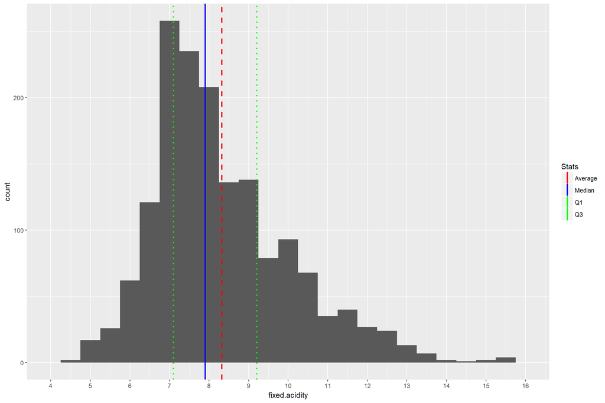

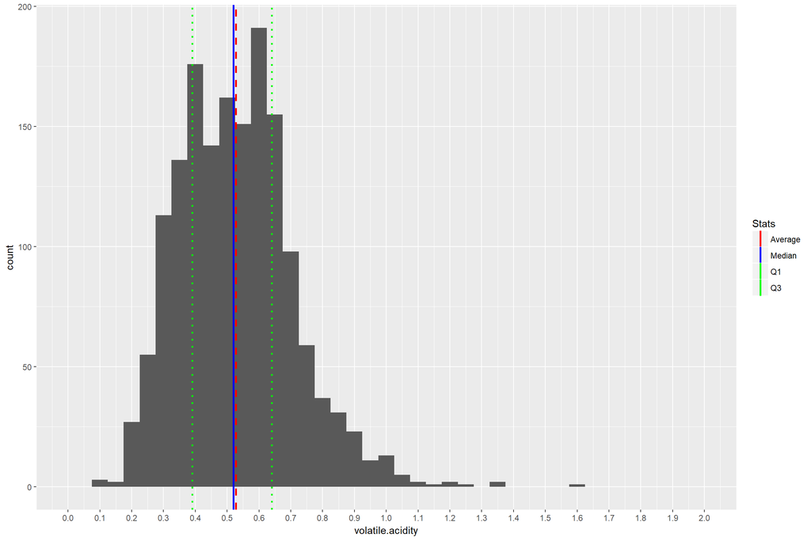

The variables *fixed.acidity* and *volatile.acidity* look normally distributed.

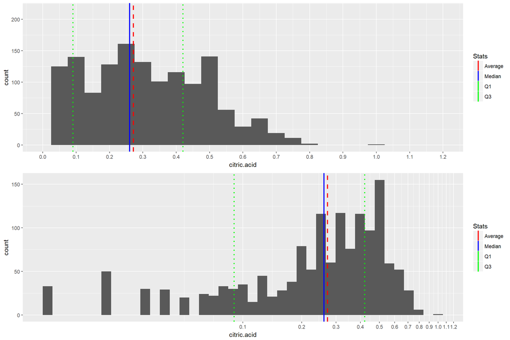

The variable *citric.acid* is very skewed to the right. The log transform shows a peak between 0.4 and 0.5.

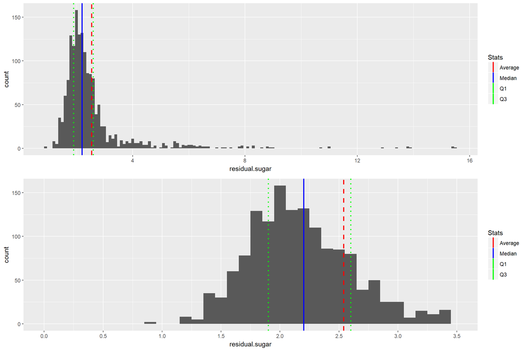

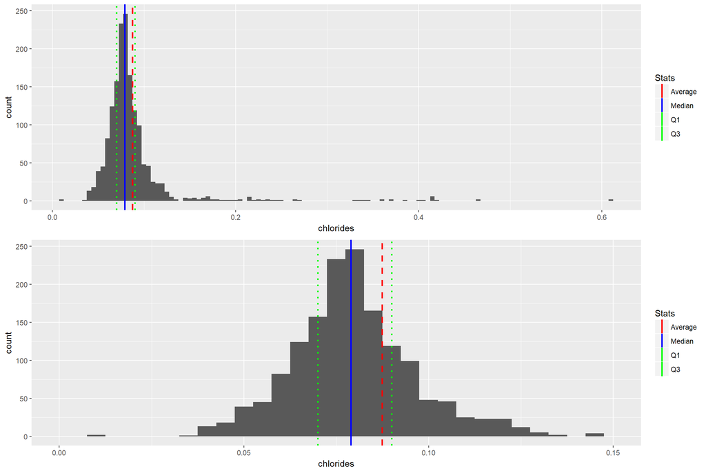

The variables *residual.sugar* and *chlorides* look normally distributed, but both have very distant outliers.

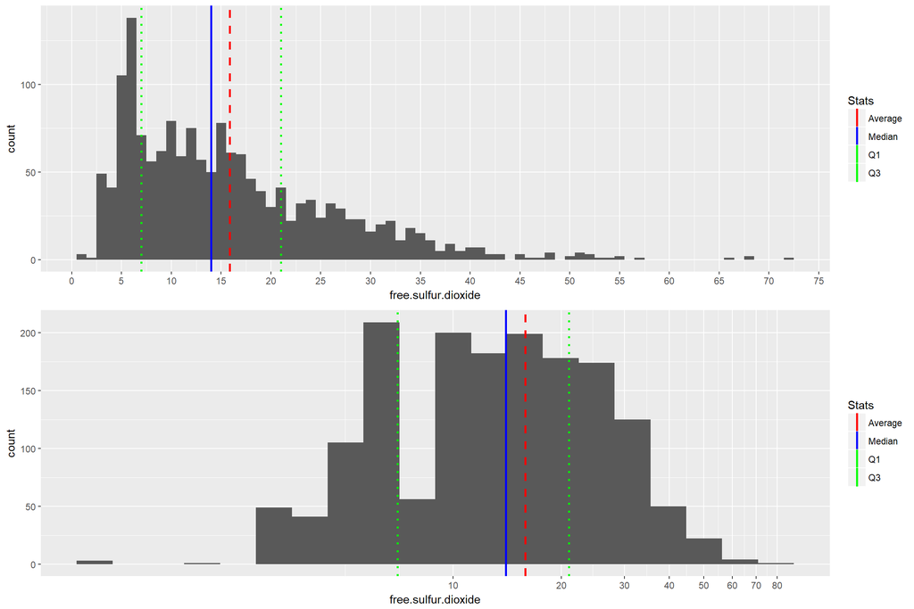

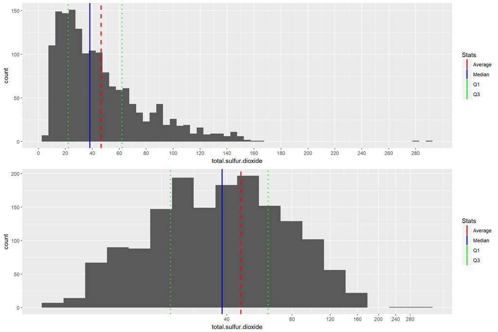

Both *free.sulfur.dioxide* and *total.sulfur.dioxide* are skewed to the right. The latter has very distant outliers. They look normally distributed when a log-transform is applied.

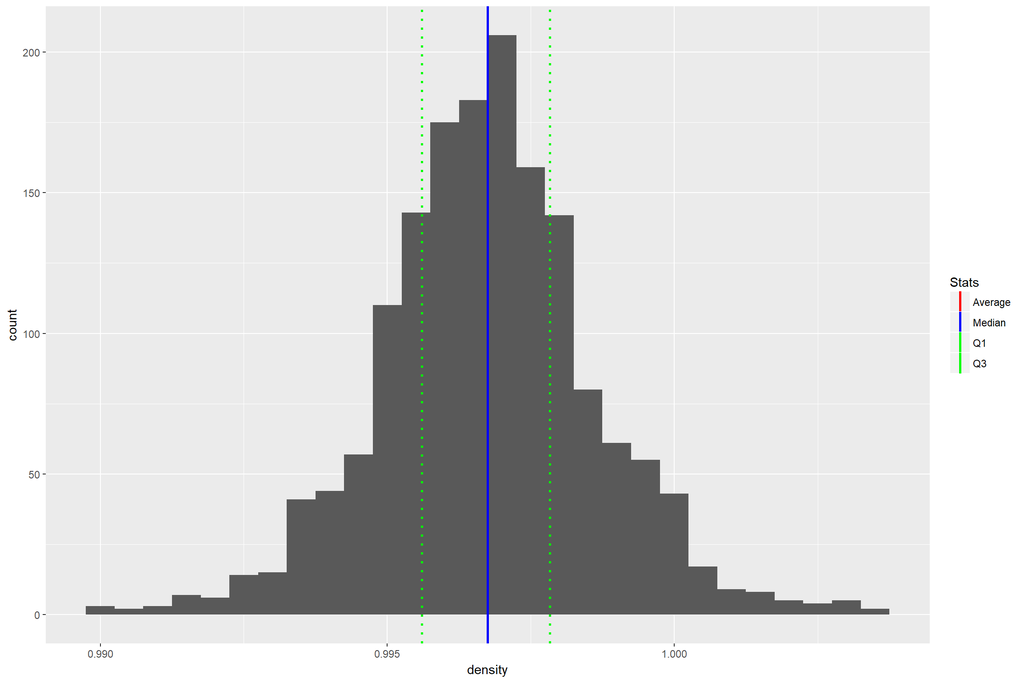

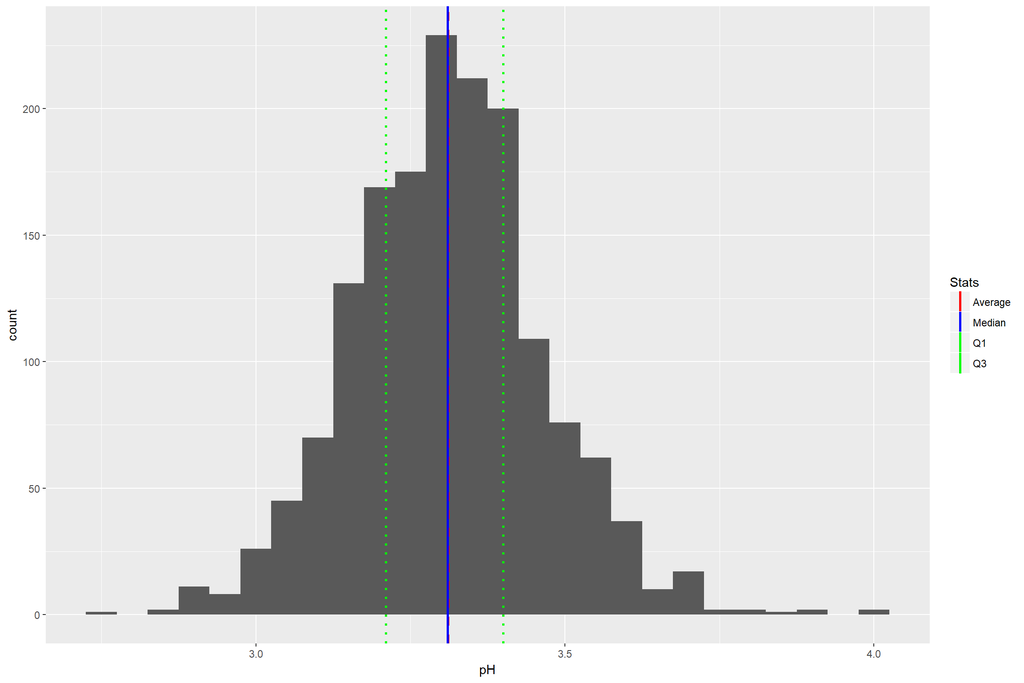

Both *density* and *pH* look normally distributed.

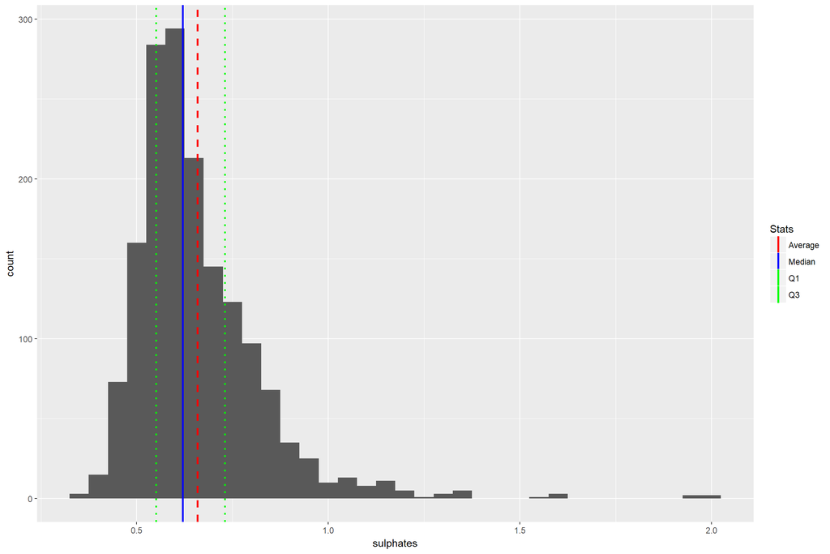

The variable *sulphates* looks normally distributed, with some outliers.

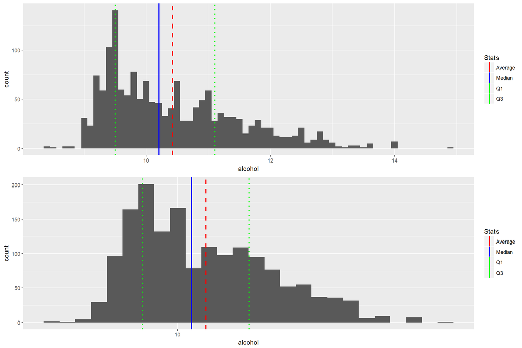

The variable *alcohol* is skewed to the right. Applying a log-transform does not change much.

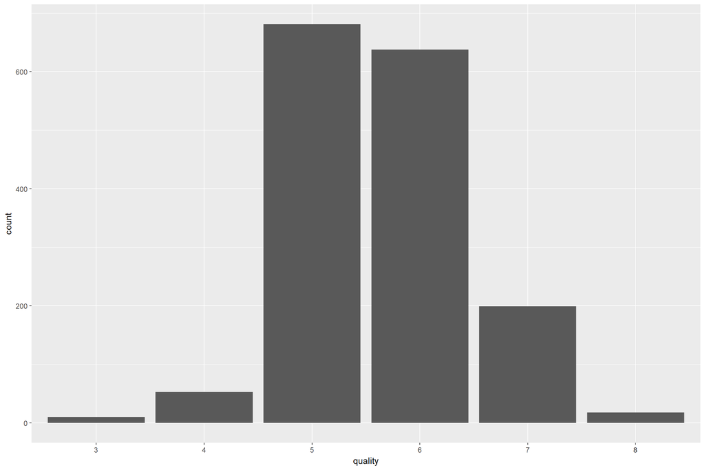

An overwhelming majority of wines, about 1300 of the total 1599, are rated five or six, and about 200 are rated seven. The rest are rated three, four or eight.

# Univariate Analysis

### What is the structure of your dataset?

There are 1599 red wines in the dataset with twelve features and an identifier number. Except *quality*, which is discrete, the rest of the features are continuous, although most of the values of *free.sulfur.dioxide* and *total.sulfur.dioxide* are whole.

### What is/are the main feature(s) of interest in your dataset?

The main feature is *quality*. I would like to know if and which ones of the other features can help determine the quality of a red wine.

### What other features in the dataset do you think will help support your investigation into your feature(s) of interest?

The info provided by the authors of the dataset gives a few tips about which variables can affect the quality of the wine, but it is far from comprehensive.

Given that most wines are rated of medium quality (five or six in a scale of zero to ten), and the fact that there are several variables with very distant outliers, points me to think that very small or very large values of certain features are fundamental in the creation of non-average wines.

### Did you create any new variables from existing variables in the dataset?

No. At this point, I cannot think of any useful transformation or combination of the current variables that results in a new one.

### Of the features you investigated, were there any unusual distributions? Did you perform any operations on the data to tidy, adjust, or change the form of the data? If so, why did you do this?

There were some right-skewed distributions. I applied a log-transform to get better insights about the distributions.

Several variables had large outliers. I created a cropped version of some of them to have more details of the bulk of the data.

# Bivariate Plots Section

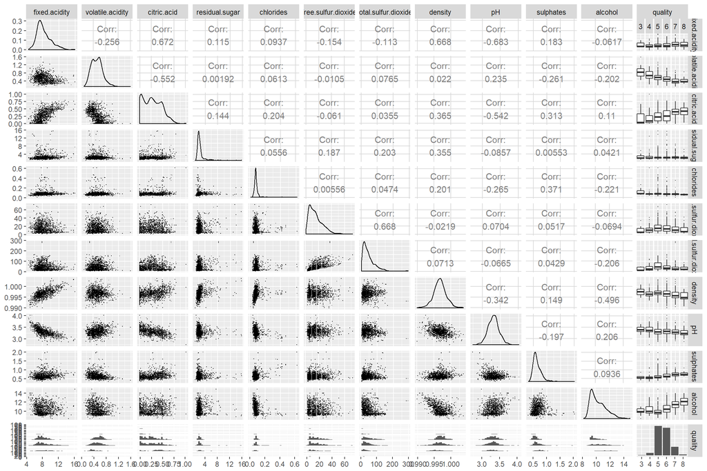

The boxplots in the matrix show correlations between *quality* and other variables: *volatile.acidity*, *citric.acid*, *sulphates* and *alcohol*. The variables *density* and *pH* might be related too, but this could be because these variables are correlated with others: *pH* with *citric.acid* and *density* with *alcohol* and *citric.acid*.

We are going to look closer into all this.

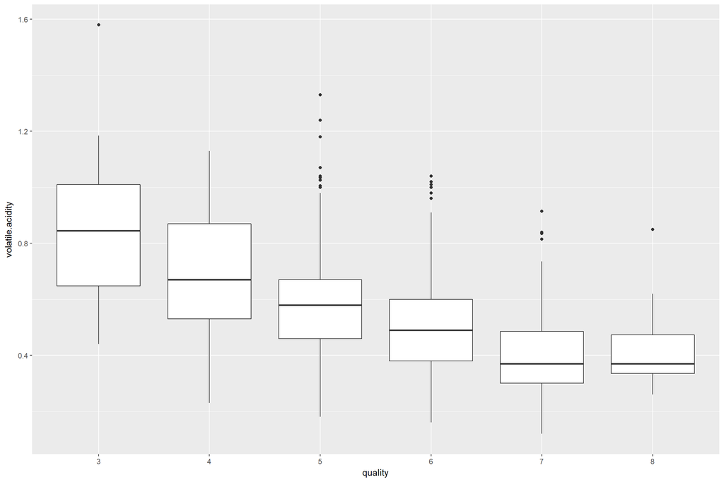

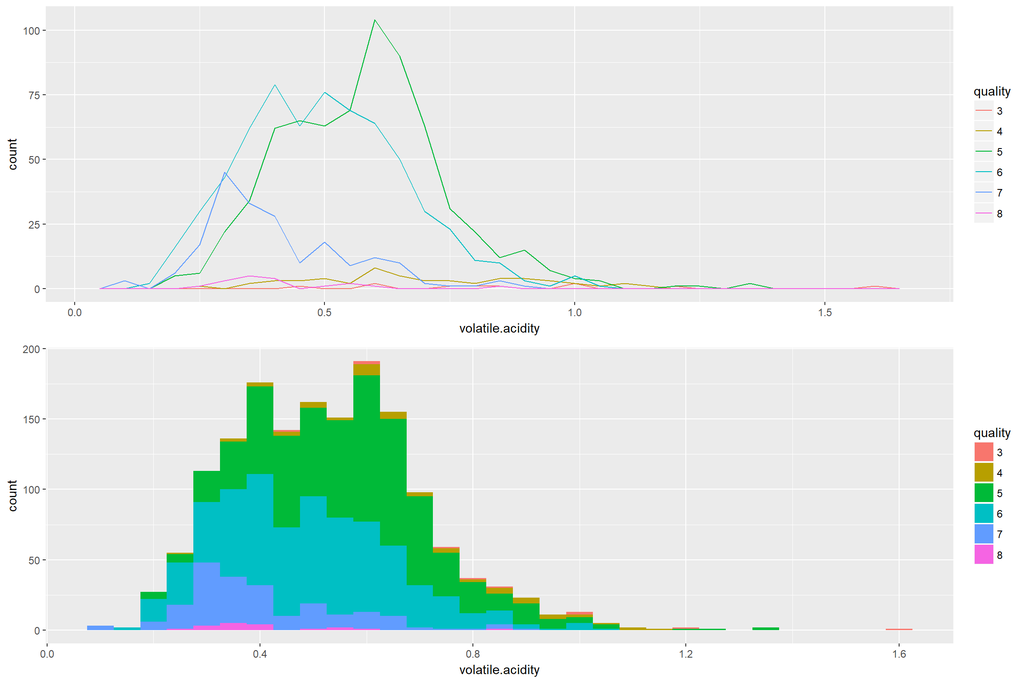

It looks like as volatile acidity increases, quality decreases, although there are two observations worth mentioning:

- Wines with a quality score of seven and eight (the best of the dataset) have similar median volatile acidity. However, the volatile acidity of wines with a quality of seven is more dispersed.
- Outliers with a quality of seven and eight have a volatile acidity similar to the median of the worst rated wines: volatile acidity alone cannot explain the differences in quality.

These findings agree with the information provided by the authors of the dataset: “too high levels can lead to an unpleasant, vinegar taste”.

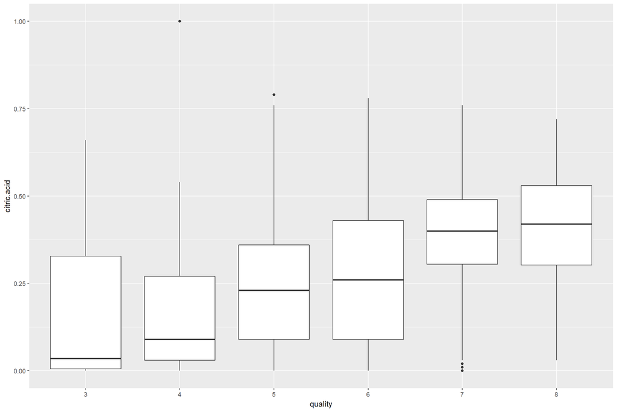

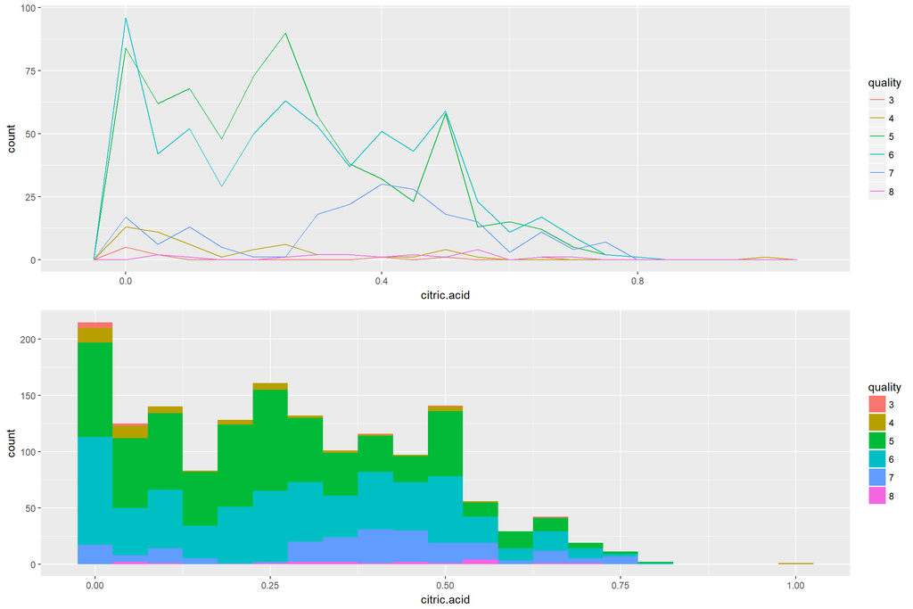

The variables *quality* and *citric.acid* are positively correlated. However, wines with a quality score of seven or eight present very similar levels of citric acid. For the rest, the amount of citric acid is very dispersed, although the median citric acid quantity for low quality wines is very low.

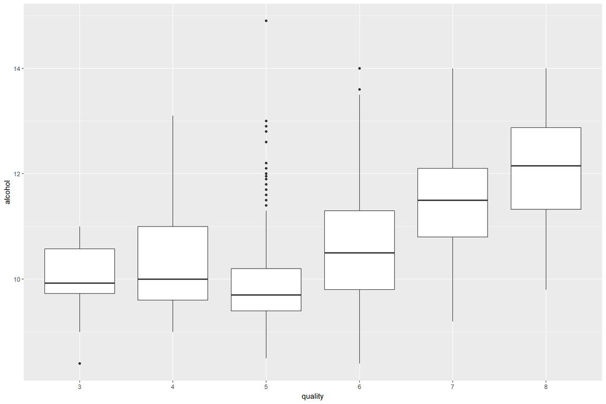

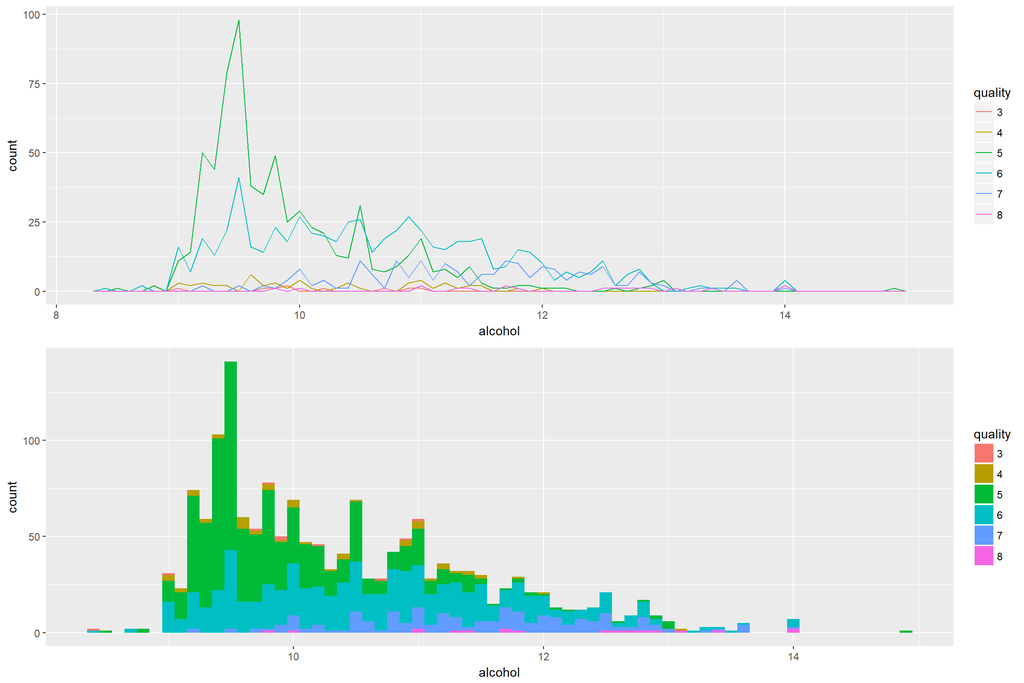

It looks like the higher the amount of alcohol content in a wine, the better the score it receives, but this effect only appears in wines with a quality of six or more, having the rest similar median values. There are a lot of outliers with a high percent of alcohol between the wines of quality five.

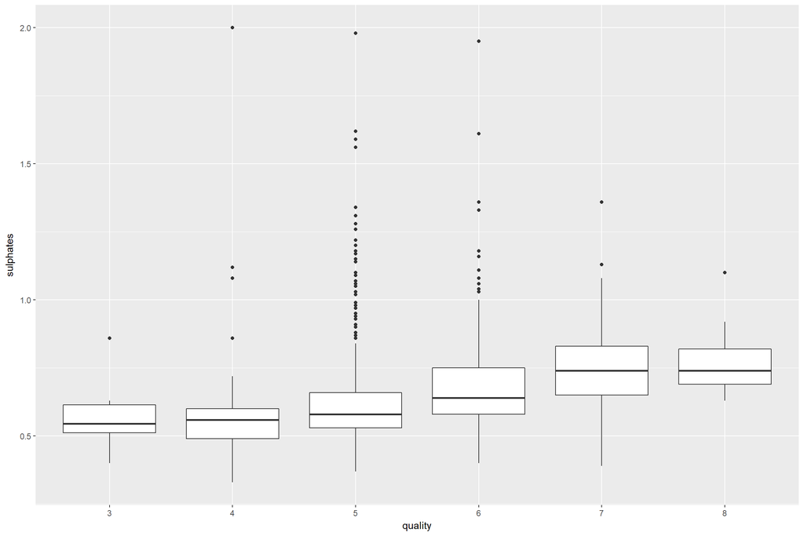

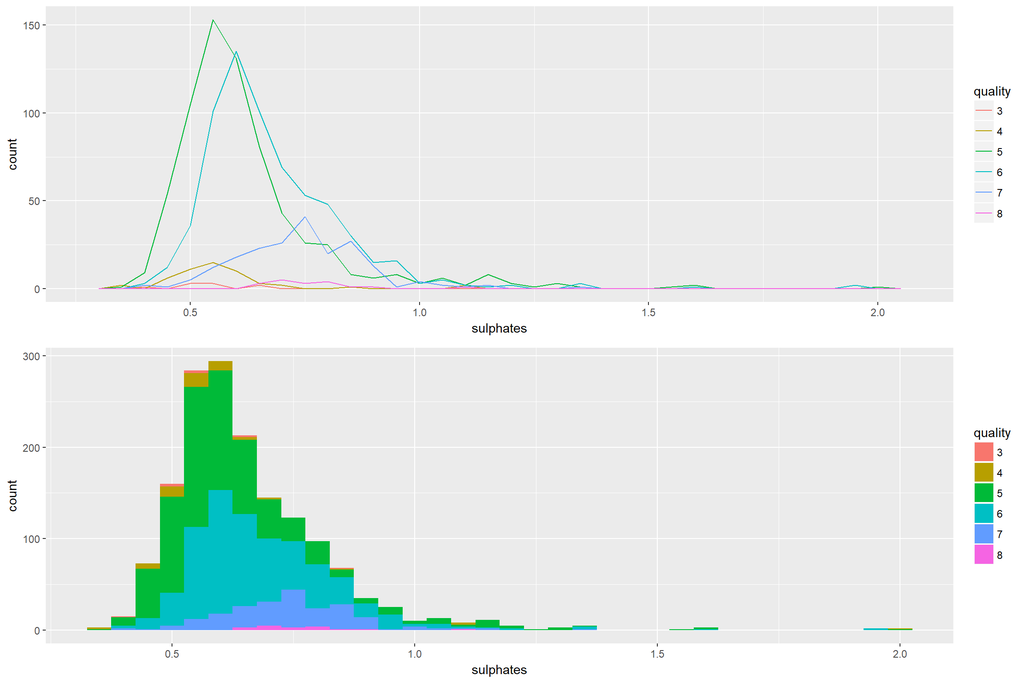

The amount of sulphates is slightly positively correlated with the quality of the wine, but the effect is not as pronounced as with the other variables mentioned above. There are a lot of outliers.

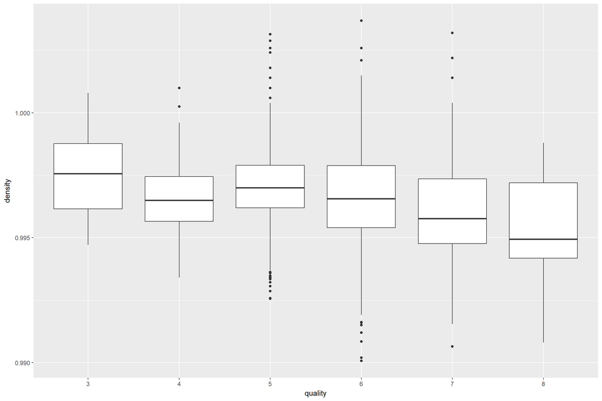

It seems to exist a mild negative correlation between *density* and *quality*. I doubt the experts can detect such small variations in density between different wines, or even care about it. My guess is that this is due to *density* being correlated with other influential variables, like *alcohol*, or just pure randomness.

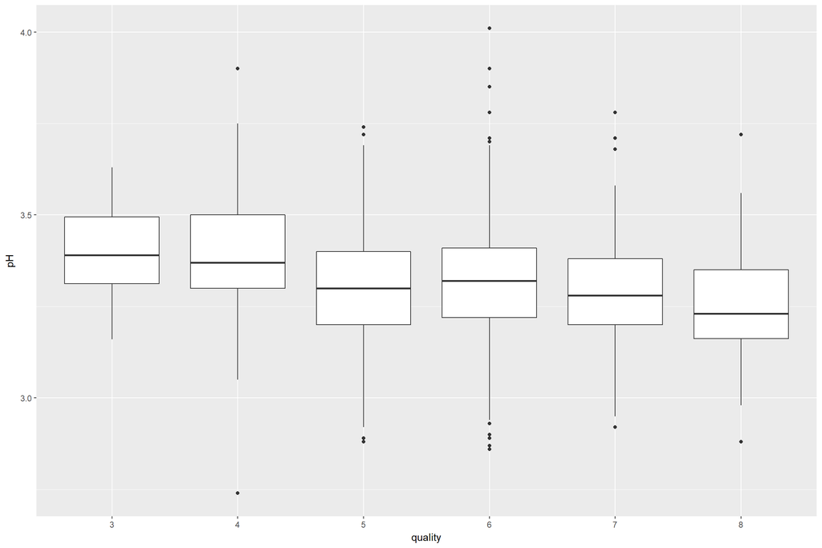

This is similar to the last case. Can we detect with our sense of taste differences in pH of one unit maximum?. Maybe this is caused by the existing negative correlation between *pH* and *citric.acid*.

There are correlations of [moderate strength](https://books.google.es/books/about/Straightforward_Statistics_for_the_Behav.html?id=8Ca2AAAAIAAJ) between some of these variables. It might be interesting to have a closer look:

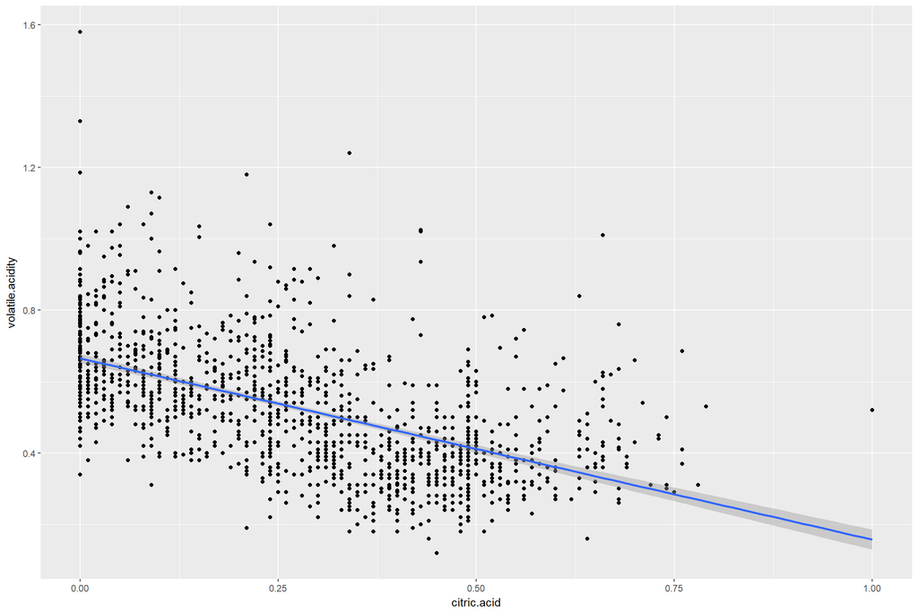

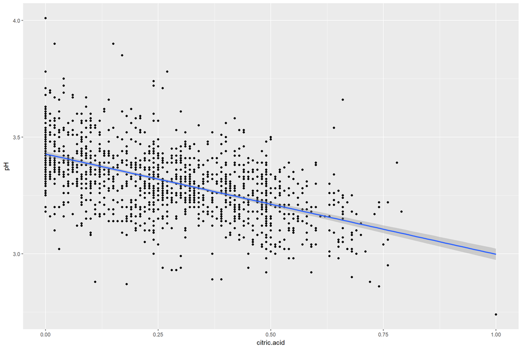

Both *volatile.acidity* and *pH* are negatively correlated with *citric.acid* (-0.552 and -0542, respectively). The latter makes sense: low pH values indicate acidity.

The relation between acetic acid (*volatile.acidity*) and citric acid is not that clear. Acordding to [Wikipedia](https://en.wikipedia.org/wiki/Acids_in_wine): “When citric acid is added, it is always done after primary alcohol fermentation has been completed due to the tendency of yeast to convert citric into acetic acid.” Maybe low levels of citric acid are a sign that it was added prematurely.

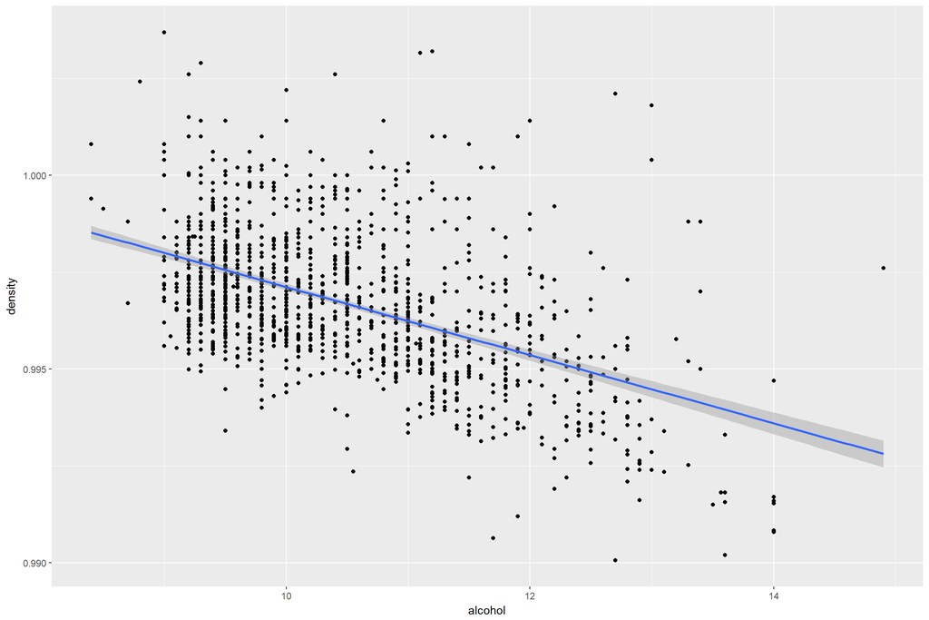

High levels of alcohol are asociated with low density (-0.496), which makes sense, since alcohol is less dense than water, the [main component](http://www.terroir-france.com/wine/components.htm) of wine.

# Bivariate Analysis

### Talk about some of the relationships you observed in this part of the investigation. How did the feature(s) of interest vary with other features in the dataset?

The data suggests that *alcohol*, *citric.acid* and *volatile.acidity* are the most decisive features for the quality of a wine, having the first two a positive correlation with *quality* and the latter a negative one. However, a far from negligible number of wines of any quality can be found along (almost) the whole spectrum of these features: none of them alone nor combined can fully explain quality, not even close.

Another three features are weakly correlated with *quality*: *sulphates*, *density* and *pH*.

### Did you observe any interesting relationships between the other features (not the main feature(s) of interest)?

*Citric.acid* is negatively correlated with both *volatile.acidity* and *pH*. *Alcohol* is inversely correlated with *density*. This may explain why *density* and *pH*, that are (I presume) hard to detect without tools are correlated with *quality*, even if weakly.

### What was the strongest relationship you found?

It is not easy to say between the three that are mentioned above. The overall strength of the relationships between *quality* and *alcohol*, *citric.acid* and *volatile.acidity* look similar. However, these relationships are not exactly linear:

- Wines of the highest qualities (seven and eight) share similar levels of acetic acid (*volatile.acidity*). Maybe low quantities of acetic acid (below approximately 0.4 g/dm<sup>3</sup>) do not influence quality.
- In a similar fashion, the upward trend of *citric.acid* with respect to *quality* seem to flatten at approximately 0.4 g/dm<sup>3</sup>.
- The median quantity of alcohol in the lowest quality wines (three, four and five) is similar. There is an upward trend after that.

# Multivariate Plots Section

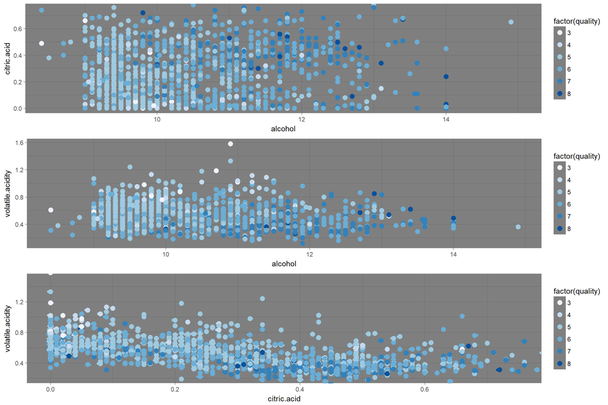

Scatter plots of the main variables, colored by *quality*. We can see the linear correlation between *volatile.acidity* and *citric.acid* (-0.552), mention aboved, and also that there is no linear correlation between *alcohol* and *citric.acid* (0.11). The correlation coefficient of *alcohol* and *volatile.acidity* is -0.202. Unfortunately, there are so many wines of quality five and six that it is hard to grasp more detailed information. We are going to examine these same plots, but removing these wines:

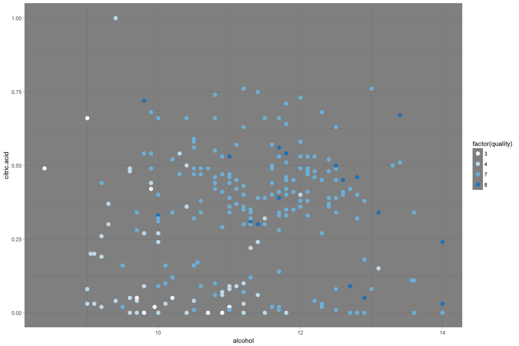

[figure not shown]

High quality wines tend to concentrate in the upper-right part of the plot. The opposite happens with bad quality ones. As suggested before, high values of *alcohol* and *citric.acid* are influential in the quality of the wine.

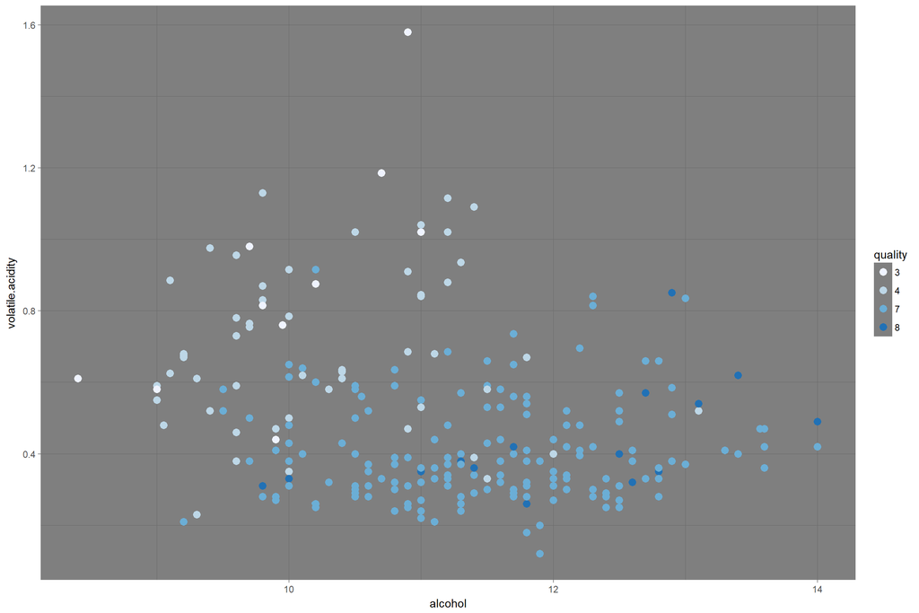

The plot shows that bad quality wines tend to have more than 0.6 g/dm<sup>3</sup> of acetic acid, while the bulk of high quality wines are below this point.

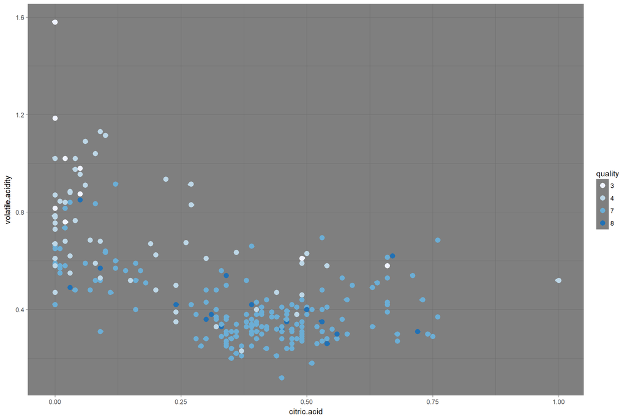

As expected, the plot shows that high *volatile.acidity* and low *citric.acid* are usually an indicator of bad quality.

We can visualize all these features together in the same plot:

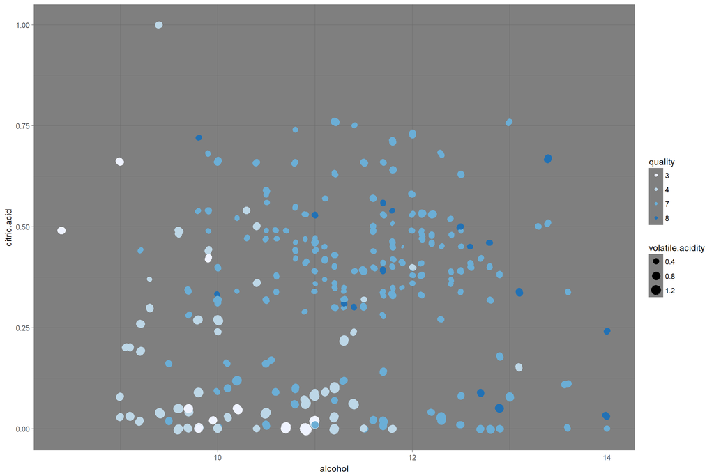

It seems that the plot confirms everything suggested by the rest of the analyisis: bad quality wines tend to have high values of *volatile.acidity* and low values of *alcohol* and *citric.acid*.